# Health Indications for Diabetes - Data Visualization

Cassandra Ortiz-Nelsen

2025-11-05

# Introduction

The dataset, “Diabetes Dataset: Predicting Diabetes Onset Based on Diagnostic Measures” is a very useful and popular tool for machine learning and health research pertaining to health indicators so health professionals can better predict this disease. This report illustrates that with robust datasets, helpful charts and cross-tabulations are possible to visualize data and make decisions.

# Information about the Data

This data set includes data from 768 female patient records, adapted from the National Institute of Diabetes and Digestive and Kidney Diseases (NIDDK). It provides insight for variables such as: age, BMI, glucose, blood pressure, and insulin.

This data can indicate whether a patient is more at risk for diabetes based on the limits acknowledged by physicians, further, this data set provides insight into prevention thresholds which is clinically meaningful. The data collected has an array of variables, yet is simple to work with in order to discover risk patterns.

To speak briefly on less discussed health indicators, such as skin thickness, blood pressure, and insulin, it is harder to attribute a clear pattern, and have shown to be difficult disease-indicators although still useful to some degree.

A note on the participant health outcome distribution, this data is mostly balanced with ~35% with outcome and ~65% without. This means the data set is robust, reducing bias.

A cross tabulation analysis was run to illustrate the relationship between diabetes and BMI. This cross-tabulation clearly shows that with a greater prevalence of diabetes, the patients will most likely be on the higher end of the BMI range. Further, when someone is in the danger zone of the BMI range, they can start to take action to prevent diabetes if informed in time.

# Variable Definitions

Pregnancies: Number of times the patient has been pregnant.

Glucose: Plasma glucose concentration after a 2-hour oral glucose tolerance test.

BloodPressure: Diastolic blood pressure (mm Hg).

SkinThickness: Triceps skinfold thickness (mm).

Insulin: 2-hour serum insulin (mu U/ml).

BMI: Body mass index (weight in kg/(height in m)^2).

DiabetesPedigreeFunction: A function representing the patient’s diabetes pedigree (likelihood based on family history).

Age: Age of the patient (years).

Outcome: Binary outcome indicating the presence (1) or absence (0) of diabetes.

Here is the link to the dataset: https://www.kaggle.com/datasets/hasibur013/diabetes-dataset

# Analysis Objectives

1.Summarize and model the distribution of important diagnostic health indicators.

2.Explore relationships between predictors (such as glucose, BMI, or age) and diabetes.

3.Build a reproducible workflow for exploratory data analysis for later predictive analytics in hospitals

# Sample of Data

```
## Rows: 768
## Columns: 9
## $ Pregnancies              <int> 6, 1, 8, 1, 0, 5, 3, 10, 2, 8, 4, 10, 10, 1, …
## $ Glucose                  <int> 148, 85, 183, 89, 137, 116, 78, 115, 197, 125…
## $ BloodPressure            <int> 72, 66, 64, 66, 40, 74, 50, 0, 70, 96, 92, 74…
## $ SkinThickness            <int> 35, 29, 0, 23, 35, 0, 32, 0, 45, 0, 0, 0, 0, …
## $ Insulin                  <int> 0, 0, 0, 94, 168, 0, 88, 0, 543, 0, 0, 0, 0, …
## $ BMI                      <dbl> 33.6, 26.6, 23.3, 28.1, 43.1, 25.6, 31.0, 35.…
## $ DiabetesPedigreeFunction <dbl> 0.627, 0.351, 0.672, 0.167, 2.288, 0.201, 0.2…
## $ Age                      <int> 50, 31, 32, 21, 33, 30, 26, 29, 53, 54, 30, 3…
## $ Outcome                  <int> 1, 0, 1, 0, 1, 0, 1, 0, 1, 1, 0, 1, 0, 1, 1, …
```

| **Characteristic** | **N = 768**<sup>1</sup> |
| --- | --- |
| Pregnancies | 3 (1, 6) |
| Glucose | 117 (99, 141) |
| Blood Pressure | 72 (62, 80) |
| Skin Thickness | 23 (0, 32) |
| Insulin | 31 (0, 128) |
| BMI | 32 (27, 37) |
| Diabetes Pedigree Function | 0.37 (0.24, 0.63) |
| Age | 29 (24, 41) |
| Outcome | 268 (35%) |

<sup>1</sup> Median (Q1, Q3); n (%)

# BMI and Glucose Distribution

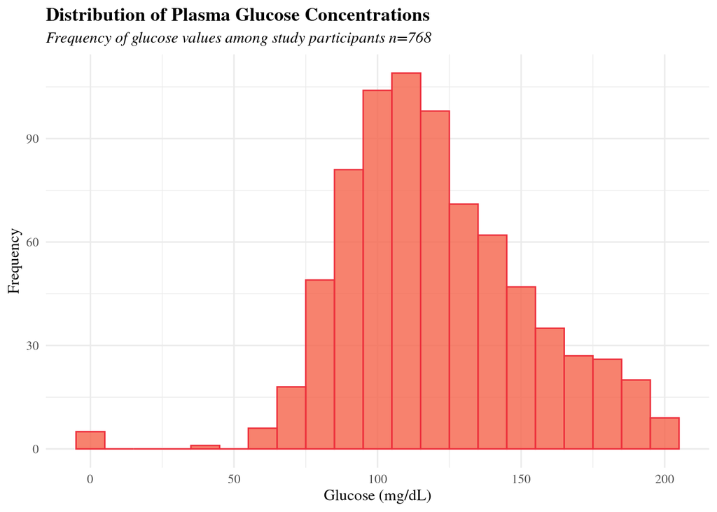

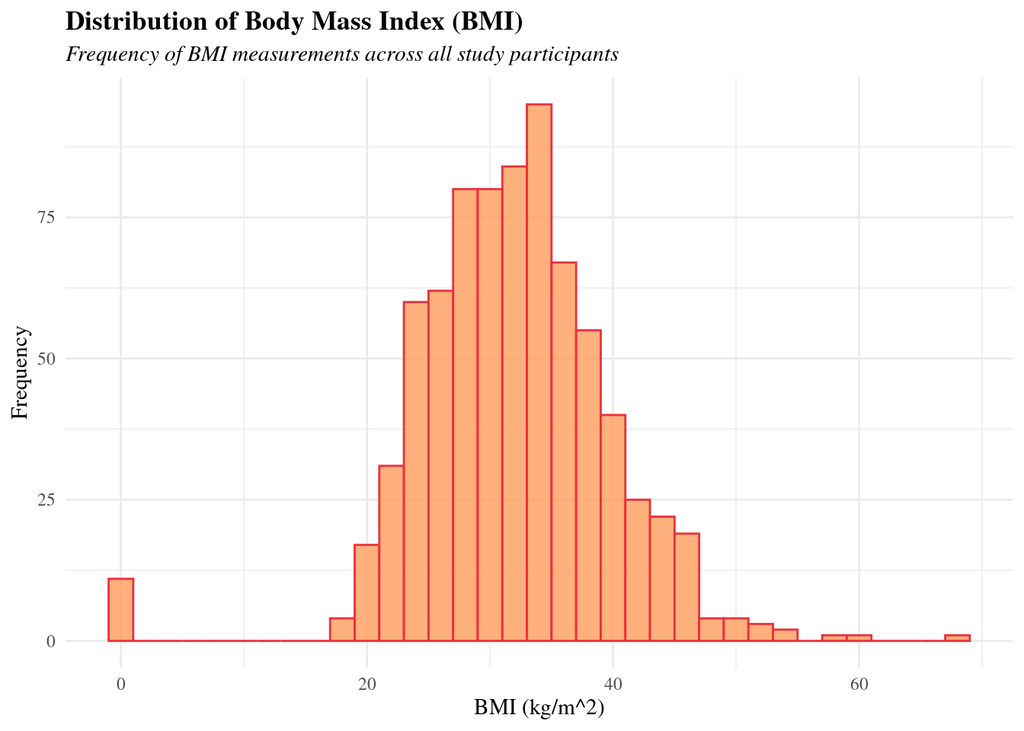

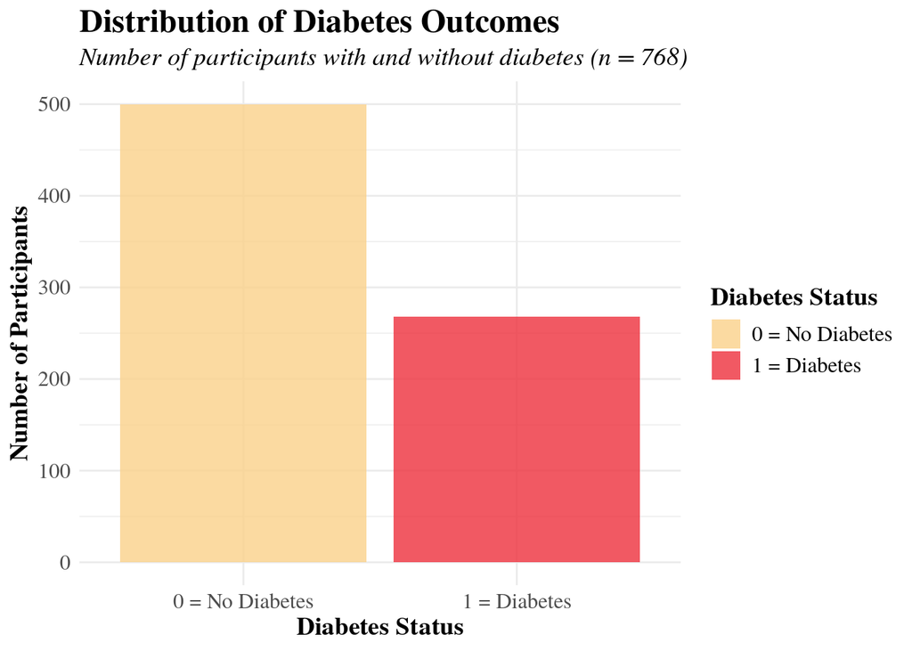

[figure not shown]

Distribution of Diabetes Outcomes (0 = No, 1 = Yes)

| Outcome | n | Percent |
| --- | --- | --- |
| No Diabetes | 500 | 65.1 |
| Diabetes | 268 | 34.9 |

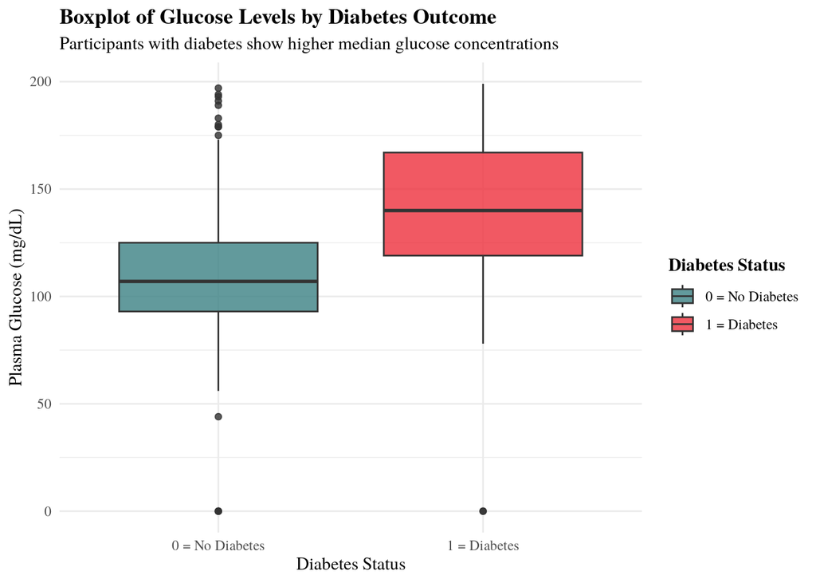

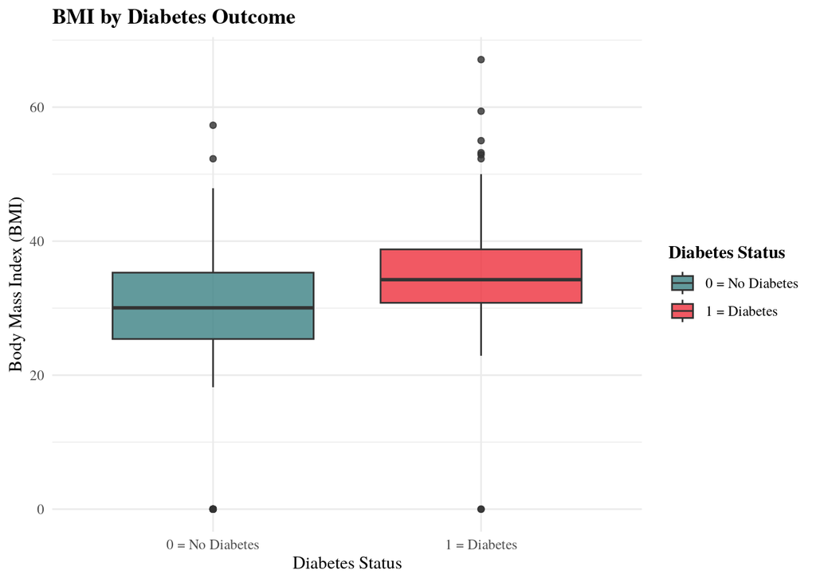

**Cross-tabulation of BMI Category, Diabetes Status, and Mean Glucose Levels**

| BMI Category | Diabetes Status | Count | Percent (%) | Mean Glucose (mg/dL) |
| --- | --- | --- | --- | --- |
| Underweight | 0 = No Diabetes | 13 | 86.7 | 99.1 |
| Underweight | 1 = Diabetes | 2 | 13.3 | 120.0 |
| Normal | 0 = No Diabetes | 95 | 93.1 | 104.3 |
| Normal | 1 = Diabetes | 7 | 6.9 | 157.6 |
| Overweight | 0 = No Diabetes | 139 | 77.7 | 112.0 |
| Overweight | 1 = Diabetes | 40 | 22.3 | 131.4 |
| Obese | 0 = No Diabetes | 253 | 53.6 | 111.5 |
| Obese | 1 = Diabetes | 219 | 46.4 | 142.7 |